# Problem of extreme values in stock prices

As we know, the stock prices in `DataStream` produce very extreme values for the Target Price Expected Return(TPER) when we divide an analyst target price over the stock price: $TPER = TP/P-1$

The following stocks have adjusted price of 2 cents which seems to be a database anomaly as I downloaded various times and got the same result:

```
##          Date Stock priceAdj
## 1: 2003-07-24   CNC     0.02
## 2: 2006-10-31   SGI     0.02
## 3: 2007-09-10   DAL     0.02
```

I, then, turn to another stock price database from `finance.yahoo.com`. Surprisingly, this source has different prices for the same stocks:

```
##          Date Stock priceAdj yahoo meanPT
## 1: 2003-07-24   CNC     0.02 14.51   14.5
## 2: 2006-10-31   SGI     0.02 31.01   31.0
## 3: 2007-09-10   DAL     0.02 17.29   20.0
```

Notice, that average price target (`meanPT`) for the sames stock is very close to the values of the `yahoo` prices. Giving the fact that `yahoo` seems to have a better stock prices information, I have created three stock prices sets. One is the `DataStream (DS)`, for the second, I completely substitute all prices in my analysis by the `yahoo (YH)` prices, and third is replaced prices only for anomalous stocks with the `yahoo (Fix)` prices. Here are plots of `TPER` for each of the sets:

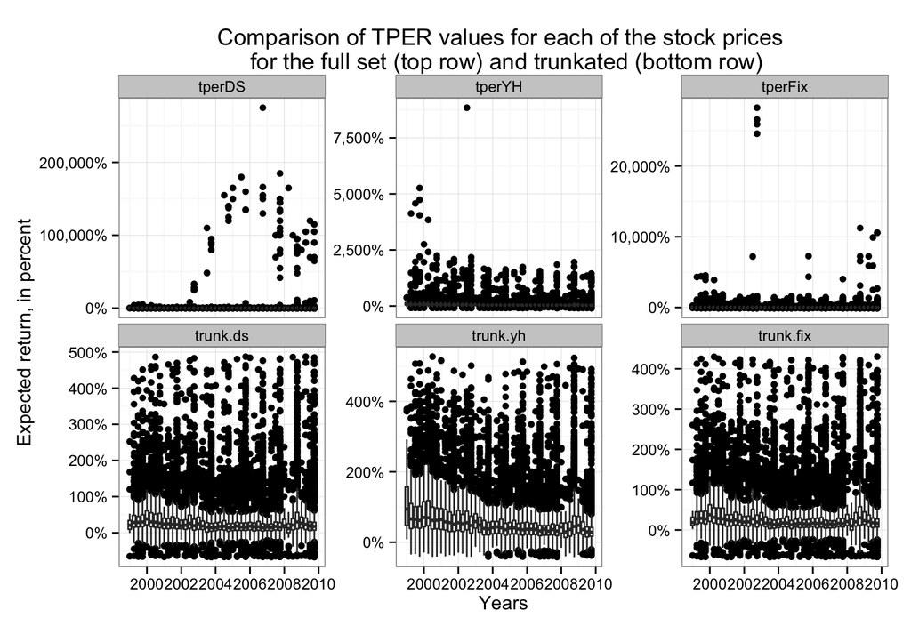

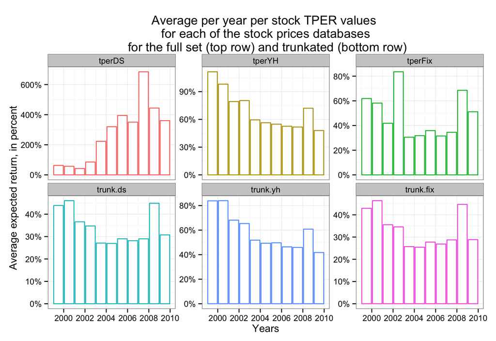

Looking at average per year plot, observe that the `Fix` dataset seems cured the anomaly in the `DataStream` sets as values mostly uniformly distributed. Now we have two options whether to switch completely to the `yahoo` prices or to use `yhaoo` prices for the selected stocks and keep all others from the `DataStream`.